# lab 10

Anne-Marie Parkinson and Hannah Garcia-something

December 3, 2019

```r
library(tidyverse)
library(janitor)
```

```r
library(corrplot)
library(beepr)
library(praise)
library(stargazer)
library(sf)
library(gganimate)
library(transformr)
library(magick)
```

### Objectives

- multiple linear regression
- first map with sf and ggplot

### 1. learn new fun r functions

```r
beep(3) # plays sound when a code is done running can choose number from 1-12 to pick diff sounds
praise() # gives random phrases of praise'
```

```
## [1] "You are outstanding!"
```

```r
praise("you are totally ${adjective}! Super ${EXCLAMATION}") # use ${ } with function of praise inside to create custom phrases with cycled adjectives, etc.
```

```
## [1] "you are totally lovely! Super AW"
```

### 2. multiple linear regression: SLO home prices

```r
#load data
homes <- read_csv("slo_homes.csv") %>%
  clean_names()
# sub data: only include data from 3 cities
homes_sub <- homes %>%
  filter(city %in% c("San Luis Obispo", "Atascadero", "Arroyo Grande"))
```

are there correlations btw variables that we’d consider ewhile trying to model home price?

```r
homes_cor <- cor(homes_sub [2:5]) # brackets= means only consider these columns
homes_cor
```

```
##               price  bedrooms bathrooms     sq_ft
## price     1.0000000 0.3115258 0.4991453 0.6618575
## bedrooms  0.3115258 1.0000000 0.7519186 0.6960233
## bathrooms 0.4991453 0.7519186 1.0000000 0.8046112
## sq_ft     0.6618575 0.6960233 0.8046112 1.0000000
```

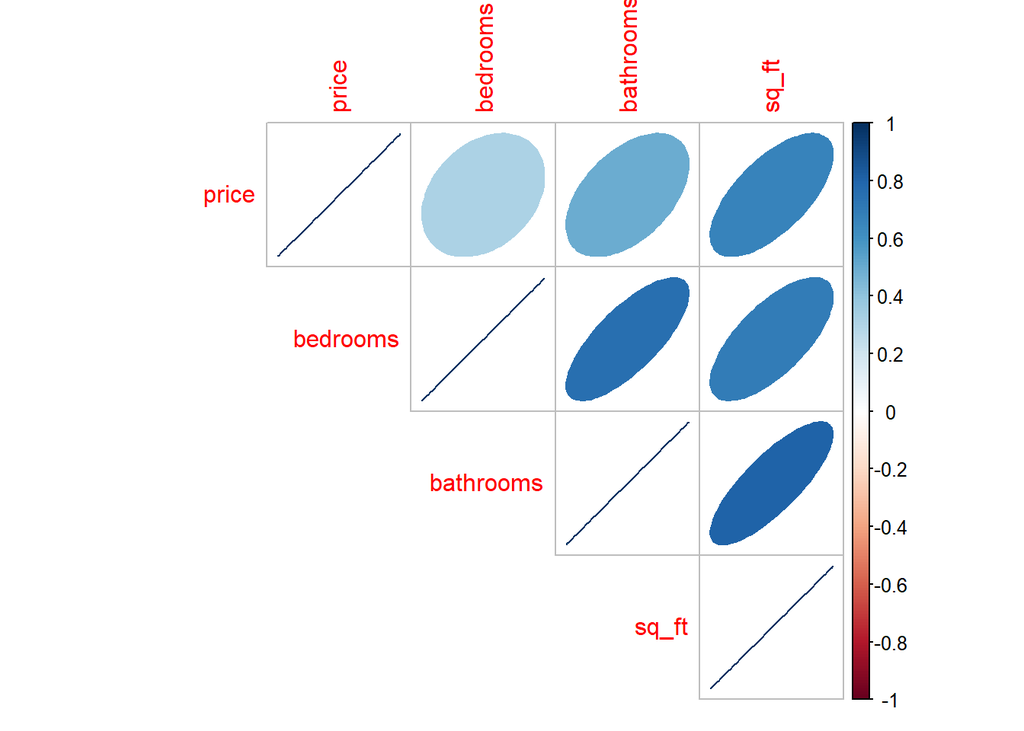

```r
corrplot(homes_cor,
         method = "ellipse",
         type = "upper")
```

```r
#=visualize correlation btw variables. have to create the correltaion matrix then use that data in corrplot(), cant put original data in corrplot()
# corrplot is redudant so add in type parameter to limit the graph so only shows the relationship btw variables once instead of twice (which is confusing)
```

also use scatterplots to examine correlations

```r
#ggplot ()+ geom_point()
```

lets start with a complete model (city, bedrooms, bathrooms, sq ft, and sale status)

```r
homes_lm <- lm(formula = price ~ city + bathrooms+ bedrooms + sq_ft + status, data=homes_sub)

summary(homes_lm)
```

```
##
## Call:
## lm(formula = price ~ city + bathrooms + bedrooms + sq_ft + status,
##     data = homes_sub)
##
## Residuals:
##     Min      1Q  Median      3Q     Max
## -843938 -115963  -12298  109718 3445077
##
## Coefficients:
##                       Estimate Std. Error t value Pr(>|t|)
## (Intercept)          184130.93  143368.84   1.284  0.20157
## cityAtascadero      -167396.39   78701.95  -2.127  0.03552 *
## citySan Luis Obispo   31018.14  114895.10   0.270  0.78766
## bathrooms             48692.04   52408.63   0.929  0.35476
## bedrooms            -161645.51   49414.32  -3.271  0.00141 **
## sq_ft                   389.12      53.17   7.318 3.43e-11 ***
## statusRegular        303964.64  105942.81   2.869  0.00488 **
## statusShort Sale     -19828.56   86335.35  -0.230  0.81875
## ---
## Signif. codes:  0 '***' 0.001 '**' 0.01 '*' 0.05 '.' 0.1 ' ' 1
##
## Residual standard error: 380600 on 117 degrees of freedom
## Multiple R-squared:  0.5682, Adjusted R-squared:  0.5424
## F-statistic:    22 on 7 and 117 DF,  p-value: < 2.2e-16
```

```r
# can reorder categorical variables so the one you want to be the reference to befirst in the list, bc r has the firt variable in the categorical var to be listed as the reference
```

intercept= 184,130

concerning variable= bedrooms. we expect home price to decrease by $160,000 for every additional room, which, bc weve done lit review adn understand our variables and how they influence home rpice outside of this model, we know is unrealistic.

bathrooms, baedrooms, and sq ft is essentially getting at the same thing: home size, so this colliniearity is likely causing the negative bedroom assoc. so best to choose just one var

p= 0, so out model predicts home price sig bettr than random chance

```r
homes_lm2 <- lm(price ~ sq_ft + status + city, data=homes_sub)

summary(homes_lm2)
```

```
##
## Call:
## lm(formula = price ~ sq_ft + status + city, data = homes_sub)
##
## Residuals:
##     Min      1Q  Median      3Q     Max
## -653118 -120914   -8844  101402 3644738
##
## Coefficients:
##                       Estimate Std. Error t value Pr(>|t|)
## (Intercept)         -105820.71  118697.40  -0.892   0.3745
## sq_ft                   325.03      31.54  10.306   <2e-16 ***
## statusRegular        315441.26  109749.65   2.874   0.0048 **
## statusShort Sale      31284.44   87356.11   0.358   0.7209
## cityAtascadero      -182586.90   80683.44  -2.263   0.0254 *
## citySan Luis Obispo   70278.97  115846.31   0.607   0.5452
## ---
## Signif. codes:  0 '***' 0.001 '**' 0.01 '*' 0.05 '.' 0.1 ' ' 1
##
## Residual standard error: 395100 on 119 degrees of freedom
## Multiple R-squared:  0.5268, Adjusted R-squared:  0.5069
## F-statistic: 26.49 on 5 and 119 DF,  p-value: < 2.2e-16
```

AIC: compare models (should do this after picking varibales that make the most conceptual sense)

```r
AIC(homes_lm)
```

```
## [1] 3576.834
```

```r
AIC(homes_lm2)
```

```
## [1] 3584.3
```

model 1 has lower AIC–> good example why shouldnt base decision on which model to choose, just on AIC! conceptually the first model does not make sense bc of the negative bedroom coefficient!!!

okay to use aic to pick models when don’t know which model is better.

### check assumptions for normality and homoscedasticity

for linear regression, we want to look at the distribution of the RESIDUALS!!! NOT the dist of the actual data points

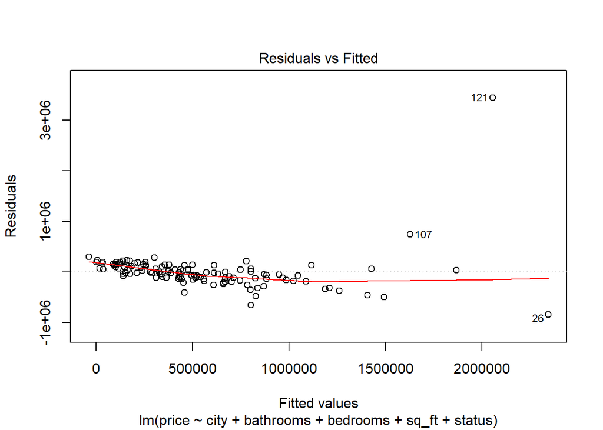

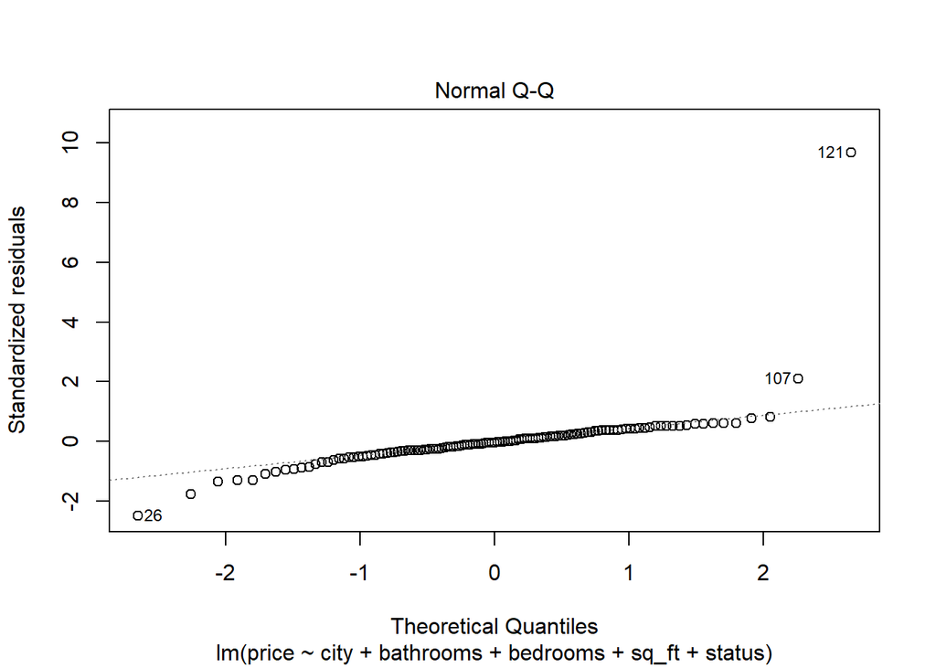

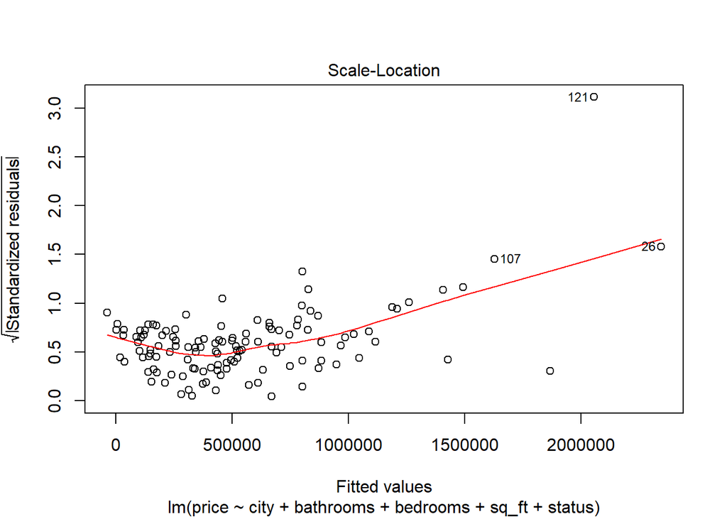

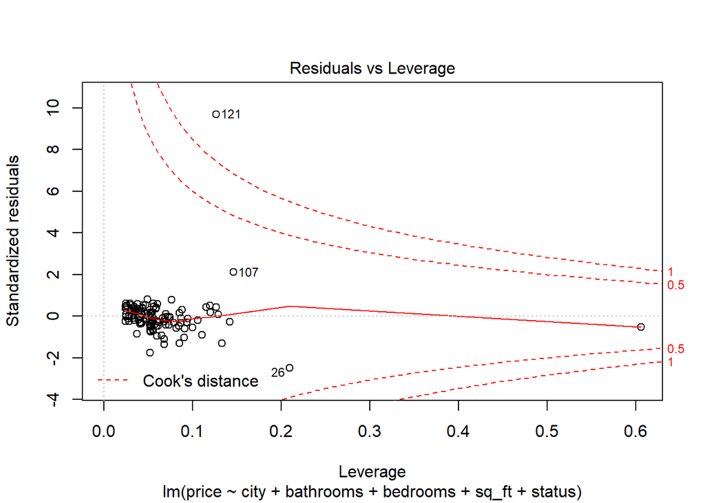

```r
plot(homes_lm)
```

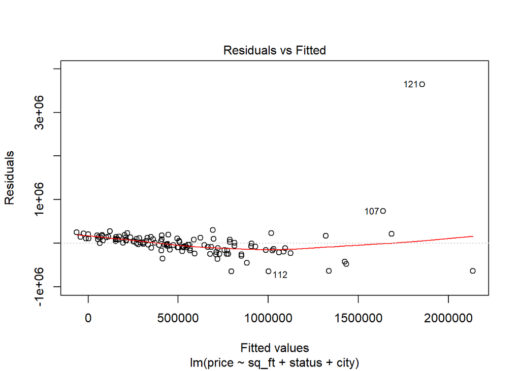

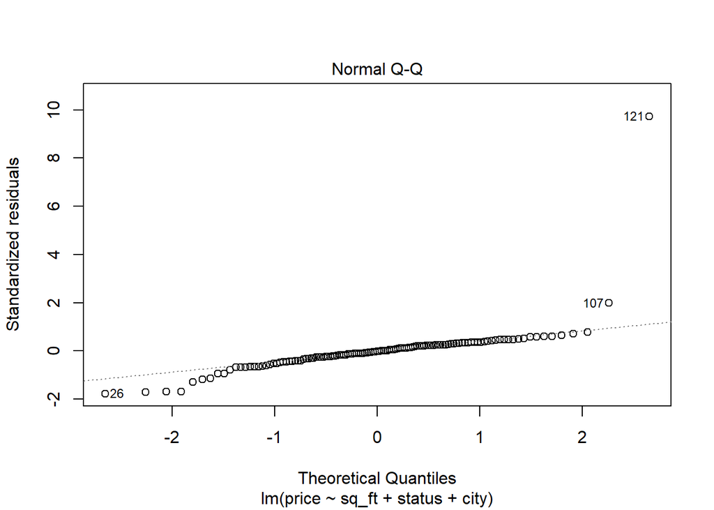

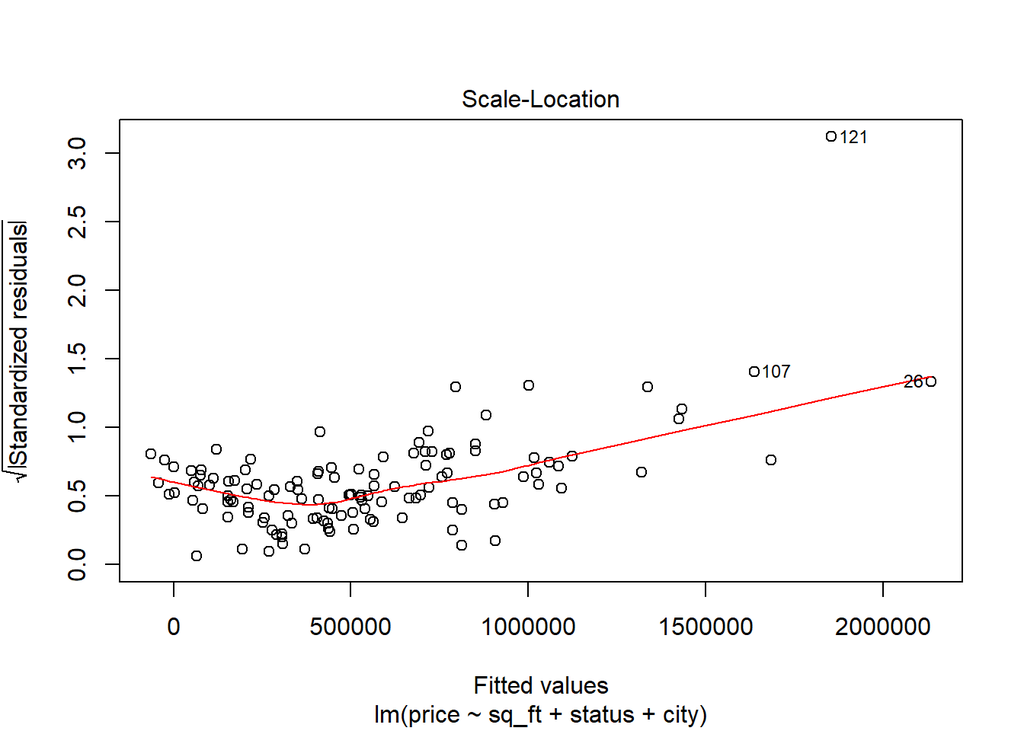

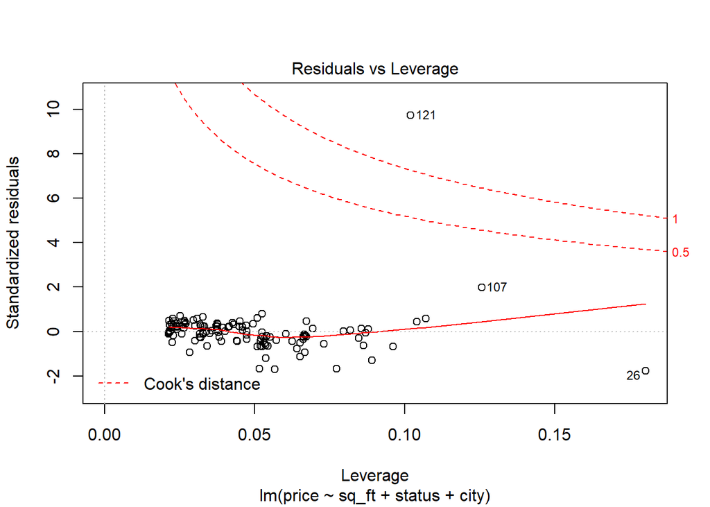

```r
# looks like assumption of constant variances of residuals (ie homoscedasicity) is met (dont let a couple outliers sway your opinion )
# assumption of residual normality is also met

plot(homes_lm2)
```

```r
# the numbers by the outlier plots refers to the row number in the data, so can look at the outliers
```

cooks dist = measure of leverage a single point has on model fit . vaue >0.5 means that value has unusually high impact on model fit. Doesnt mean you can just remove that point, should consider other factors before you do that.

make regression table using stargazer (doing it by hand is a pain)

```r
# use stargazer to report results of linear regression
stargazer(homes_lm2, type='html')
```

|  | *Dependent variable:* |
| --- | --- |
|  | price |
| sq_ft | 325.028*** |
|  | (31.538) |
| statusRegular | 315,441.300*** |
|  | (109,749.700) |
| statusShort Sale | 31,284.440 |
|  | (87,356.110) |
| cityAtascadero | -182,586.900** |
|  | (80,683.440) |
| citySan Luis Obispo | 70,278.970 |
|  | (115,846.300) |
| Constant | -105,820.700 |
|  | (118,697.400) |
| Observations | 125 |
| R<sup>2</sup> | 0.527 |
| Adjusted R<sup>2</sup> | 0.507 |
| Residual Std. Error | 395,084.400 (df = 119) |
| F Statistic | 26.491*** (df = 5; 119) |
| *Note:* | p<0.1; p<0.05; p<0.01 |

ressults=‘asis’ tells r to …put table in knitted html file?

lets make some predicitons for home price based on a new data frame. make sure the variables created for the new data frame match the vairables that the model will be looking for (ie some capitalization, spelling, special characters, etc)

```r
new_df <- data.frame(
  city = rep(c("San Luis Obispo", "Arroyo Grande", "Atascadero"), each=10),
  sq_ft = rep(seq(1000, 5000, length=10)),
  status = "Regular"
)
```

Now make preditions

```r
predict_df <-  predict(homes_lm2, newdata=new_df)
predict_df
```

```
##         1         2         3         4         5         6         7
##  604927.5  749384.3  893841.2 1038298.1 1182754.9 1327211.8 1471668.7
##         8         9        10        11        12        13        14
## 1616125.5 1760582.4 1905039.3  534648.5  679105.4  823562.2  968019.1
##        15        16        17        18        19        20        21
## 1112476.0 1256932.8 1401389.7 1545846.6 1690303.4 1834760.3  352061.6
##        22        23        24        25        26        27        28
##  496518.5  640975.3  785432.2  929889.1 1074345.9 1218802.8 1363259.7
##        29        30
## 1507716.5 1652173.4
```

```r
#bind together the new df with the prediciotns so its easier to see
full_data <- data.frame(new_df, predict_df)
full_data
```

```
##               city    sq_ft  status predict_df
## 1  San Luis Obispo 1000.000 Regular   604927.5
## 2  San Luis Obispo 1444.444 Regular   749384.3
## 3  San Luis Obispo 1888.889 Regular   893841.2
## 4  San Luis Obispo 2333.333 Regular  1038298.1
## 5  San Luis Obispo 2777.778 Regular  1182754.9
## 6  San Luis Obispo 3222.222 Regular  1327211.8
## 7  San Luis Obispo 3666.667 Regular  1471668.7
## 8  San Luis Obispo 4111.111 Regular  1616125.5
## 9  San Luis Obispo 4555.556 Regular  1760582.4
## 10 San Luis Obispo 5000.000 Regular  1905039.3
## 11   Arroyo Grande 1000.000 Regular   534648.5
## 12   Arroyo Grande 1444.444 Regular   679105.4
## 13   Arroyo Grande 1888.889 Regular   823562.2
## 14   Arroyo Grande 2333.333 Regular   968019.1
```

[output cut: 16 more lines]

now plot in ggplot

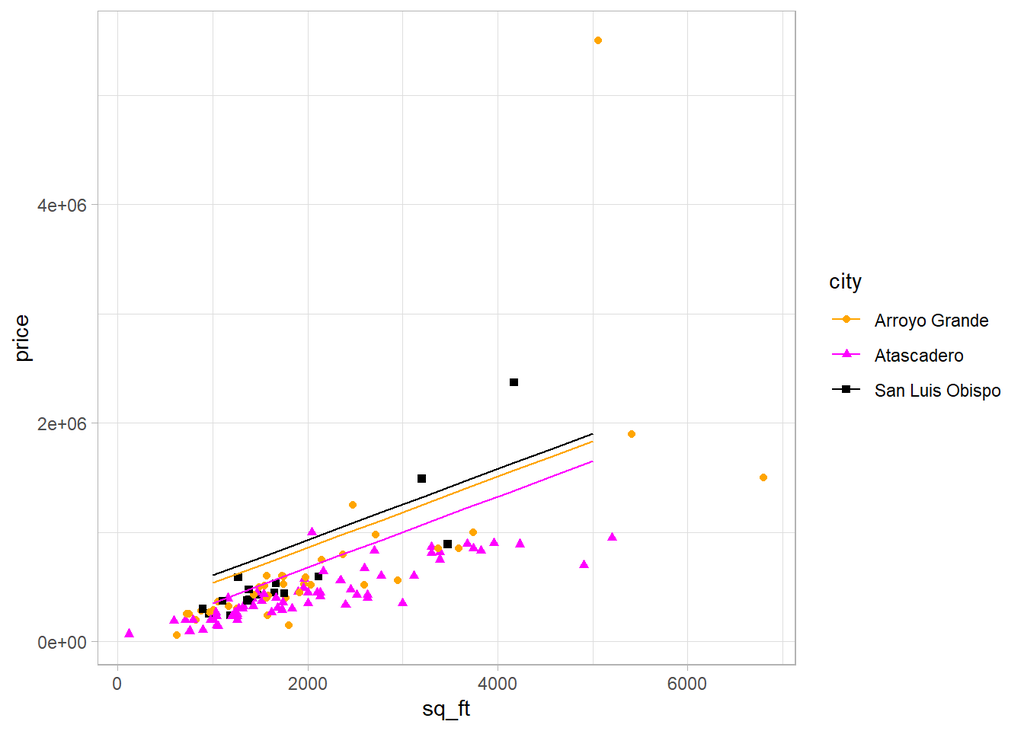

```r
ggplot() +
  geom_point(data=homes_sub,
             aes(x=sq_ft, y=price, color=city, pch=city)) +
  geom_line(data = full_data,
            aes(x = sq_ft,
                y = predict_df,
                color = city)) +
  scale_color_manual(values = c("orange", "magenta", "black")) +
  theme_light()
```

### our first map (thanks sf package)

great bc has sticky geometries. so when get bunch of spatial data with lots of attributes. So when wrangle data (ex/ select, filter, etc), all the original attributes will stick with the data point even if it doesnt show in the subdata

sf = useful for gis data and layers

```r
dams <- read_csv("ca_dams.csv") %>%
  clean_names() %>%
  drop_na(longitude) %>%
  drop_na(latitude) %>%
  drop_na(year_completed)
```

r doesnt recognize lat and longitude as spatial data. –> so convert our data frame to an sf object using st_as_sf

```r
dams_sf <- st_as_sf(dams, coords=c("longitude", "latitude"))

st_crs(dams_sf) <- 4326  # = computes/assigns coordinate system of the spatial data (lat, long)
```

make sure to input the actual column names for lat and long. some times theyre called other things like lat and long

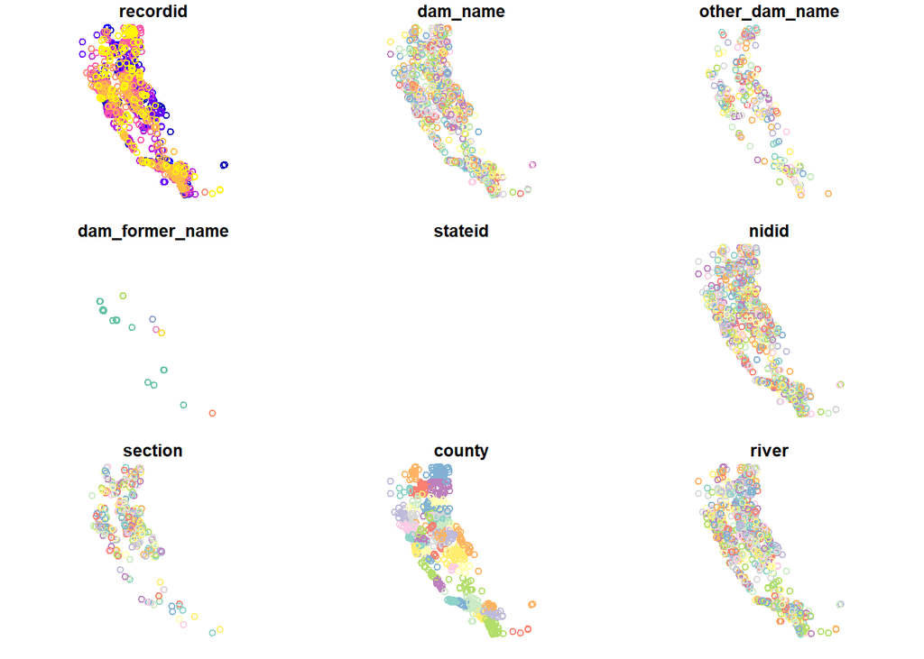

```r
#plot lat and long
plot(dams_sf)
```

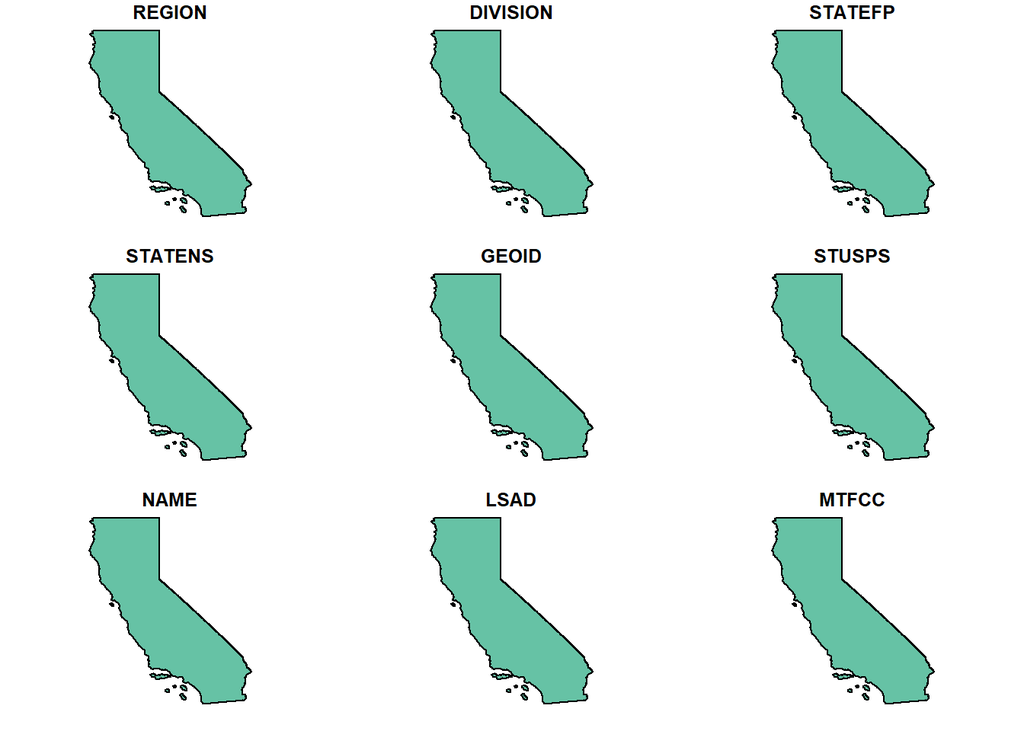

```r
# in and of its self, the points are not as intersting/meaningful, but will be when we add a spatial map to overlay the points on (ie map of CA)

#add map (CA boundary)
ca_border <-  read_sf(here::here("ca_state_border"), layer="CA_State_TIGER2016")
#shape files tend to have several files, so this code lets you read in all files with the same suffix so dont have to load the shapefiles supporting files one by one

#view(ca_border) --> = data frame for the shapefile appears as a single row. spatial data is in last column. likely to have more rows is have more states. but depends on the shapefile

plot(ca_border)
```

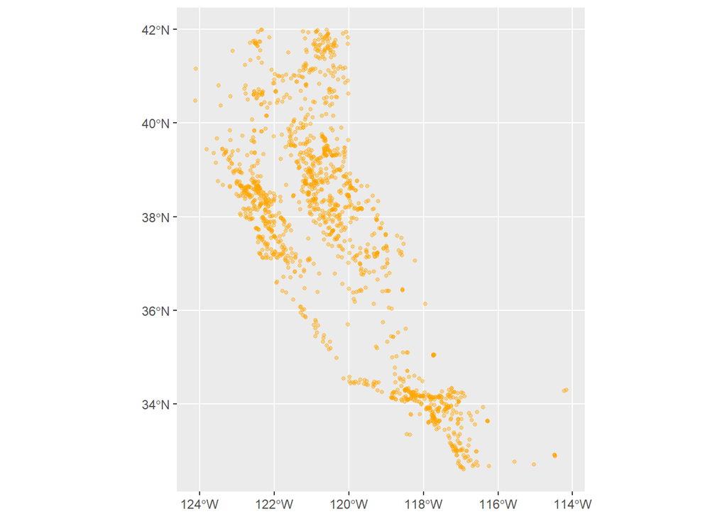

```r
ggplot() +
  geom_sf(data=dams_sf, color="orange", size=1, alpha=0.4)
```

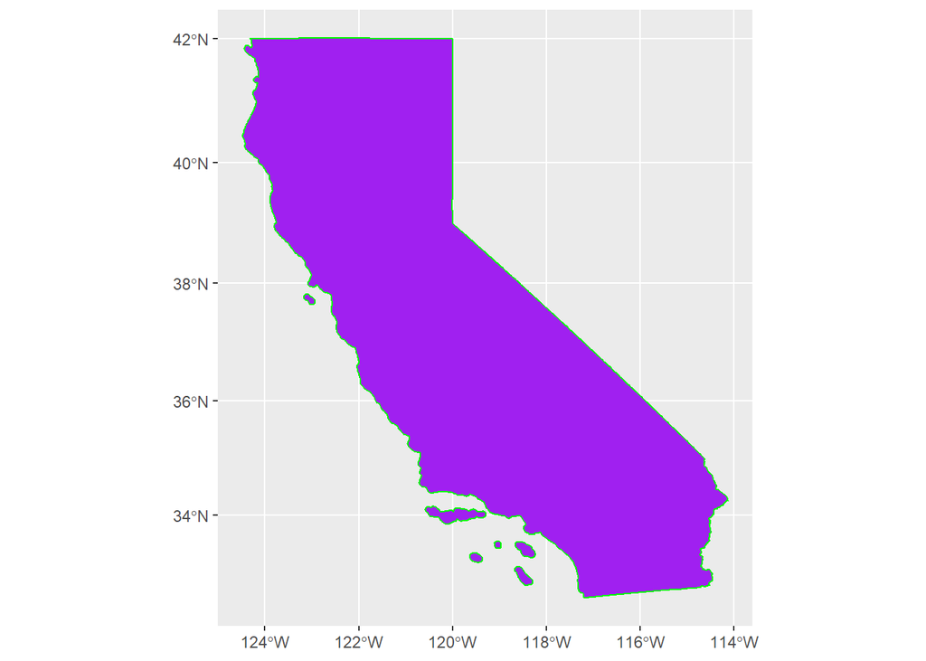

```r
ggplot()+
  geom_sf(data=ca_border, fill="purple", color="green")
```

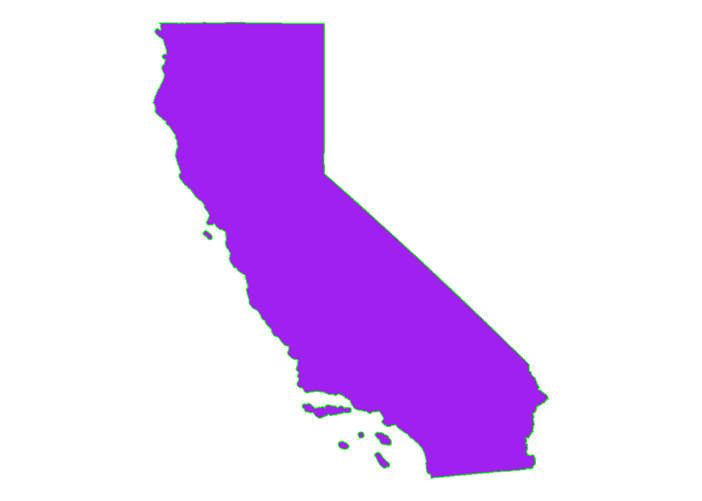

```r
ggplot()+
  geom_sf(data=ca_border, fill="purple", color="green") +
  theme_void()
```

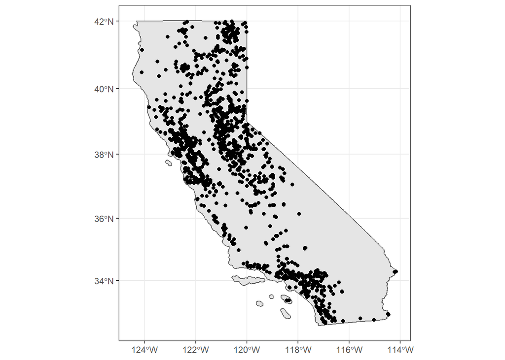

```r
ggplot() +
  geom_sf(data=ca_border) +
  geom_sf(data=dams_sf) +
  theme_bw()
```

### gganimate

animated maps dont show up in rmarkdown, so have to knit afterwards

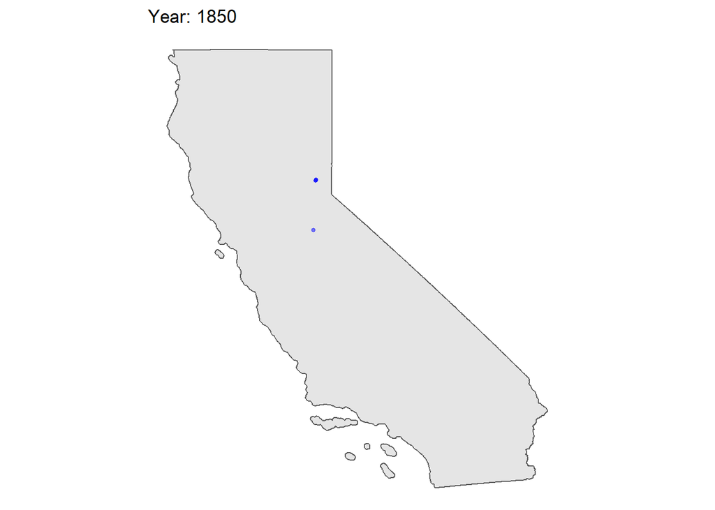

```r
ggplot() +
  geom_sf(data=ca_border) +
  geom_sf(data=dams_sf,
          color="blue",
          alpha=0.5,
          size=1) +
  theme_void() +
  labs(title='Year: {round(frame_time,0)}') + # shows title so audience knows what the points represent. frame time is not a value we created but is an sf function.
  transition_time(year_completed) +
  shadow_mark()  # default is to have points dissapear after they appear, this code makes sure they stay visable
```